# CA-3

# ASSIGNMENT

### ON

# COVID-19 INDIA DATASET

[figure not shown]

#### NAMES OF THE FILES USED:-

##### 1.patients_data.xlsx

##### 2.complete.xlsx

##### 3.AgeGroupDetails.csv

##### 4.covid_19_india.csv

##### 5.HospitalBedsIndia.csv

##### 6.IndividualDetails.csv

##### 7.ICMRTestingDetails.csv

##### 8.ICMRTestingLabs.csv

##### 9.StatewiseTestingDetails.csv

```python
import xlrd

ds=xlrd.open_workbook("patients_data.xlsx")
sheet=ds.sheet_by_index(0)
sheet.cell_value(0,0)
print(sheet.nrows)
```

```
12322
```

```python
print(sheet.ncols)
```

```
18
```

```python
import pandas as pd

ds1=pd.read_excel(r"patients_data.xlsx")
ds1.describe()
```

|  | patient_number |
| --- | --- |
| count | 12321.000000 |
| mean | 6161.599708 |
| std | 3557.326488 |
| min | 1.000000 |
| 25% | 3081.000000 |
| 50% | 6162.000000 |
| 75% | 9242.000000 |
| max | 12322.000000 |

# PROBLEM SATEMENT 1

FIRST 5 PATIENT IN INDIA

```python
ds1.head()
```

|  | patient_number | p_id | state_patient_number | date_announced | age_bracket | gender | detected_city | detected_district | detected_state | current_status | notes | suspected_contacted_patient | nationality | status_change_date | source_1 | source_2 | source_3 | backup_notes |
| --- | --- | --- | --- | --- | --- | --- | --- | --- | --- | --- | --- | --- | --- | --- | --- | --- | --- | --- |
| 0 | 1 | P1 | KL-TS-P1 | 30/01/2020 | 20 | F | Thrissur | Thrissur | Kerala | Recovered | Travelled from Wuhan | NaN | India | 14/02/2020 | https://twitter.com/vijayanpinarayi/status/122... | https://weather.com/en-IN/india/news/news/2020... | Student from Wuhan | NaN |
| 1 | 2 | P2 | KL-AL-P1 | 02/02/2020 | NaN | NaN | Alappuzha | Alappuzha | Kerala | Recovered | Travelled from Wuhan | NaN | India | 14/02/2020 | https://www.indiatoday.in/india/story/kerala-r... | https://weather.com/en-IN/india/news/news/2020... | NaN | Student from Wuhan |
| 2 | 3 | P3 | KL-KS-P1 | 03/02/2020 | NaN | NaN | Kasaragod | Kasaragod | Kerala | Recovered | Travelled from Wuhan | NaN | India | 14/02/2020 | https://www.indiatoday.in/india/story/kerala-n... | https://twitter.com/ANI/status/122422148580539... | https://weather.com/en-IN/india/news/news/2020... | Student from Wuhan |
| 3 | 4 | P4 | DL-P1 | 02/03/2020 | 45 | M | East Delhi (Mayur Vihar) | East Delhi | Delhi | Recovered | Travelled from Austria, Italy | NaN | India | 15/03/2020 | https://www.indiatoday.in/india/story/not-a-ja... | https://economictimes.indiatimes.com/news/poli... | NaN | Travel history to Italy and Austria |
| 4 | 5 | P5 | TS-P1 | 02/03/2020 | 24 | M | Hyderabad | Hyderabad | Telangana | Recovered | Travelled from Dubai to Bangalore on 20th Feb,... | NaN | India | 02/03/2020 | https://www.deccanherald.com/national/south/qu... | https://www.indiatoday.in/india/story/coronavi... | https://www.thehindu.com/news/national/coronav... | Travel history to Dubai, Singapore contact |

### Observation:-

#### 1. it shows thst the first patient with corona positive was detected in India on 30/01/2020 in city thirssur (Kerala)

#### 2.it also shows the details of the first 5 patient of corona with the details like

### patient_number

### p_id

### date_announced

### age_bracket

### gender , .

```python
ds1.dtypes
```

```
patient_number                  int64
p_id                           object
state_patient_number           object
date_announced                 object
age_bracket                    object
gender                         object
detected_city                  object
detected_district              object
detected_state                 object
current_status                 object
notes                          object
suspected_contacted_patient    object
nationality                    object
status_change_date             object
source_1                       object
source_2                       object
source_3                       object
backup_notes                   object
dtype: object
```

```python
ds1['patient_number'].count()
```

```
12321
```

```python
ds1['detected_state'].value_counts()
```

```
Maharashtra                    2916
Delhi                          1561
Tamil Nadu                     1242
Rajasthan                      1046
Madhya Pradesh                  938
Gujarat                         766
Uttar Pradesh                   735
Telangana                       650
Andhra Pradesh                  525
Kerala                          387
Jammu and Kashmir               300
Karnataka                       279
West Bengal                     213
Haryana                         204
Punjab                          186
Bihar                            70
Odisha                           60
Uttarakhand                      37
Himachal Pradesh                 35
Chhattisgarh                     33
Assam                            32
Jharkhand                        28
Chandigarh                       21
Ladakh                           17
Andaman and Nicobar Islands      11
Goa                               7
Meghalaya                         7
Puducherry                        7
Manipur                           2
Tripura                           2
Arunachal Pradesh                 1
Mizoram                           1
Dadra and Nagar Haveli            1
Nagaland                          1
Name: detected_state, dtype: int64
```

```python
import pandas as pd
import matplotlib.pyplot as plt
```

# PROBLEM STATEMENT 2:-

WHAT IS THE PERCENTAGE OF THE AFFECTED (GENDERWISE):-

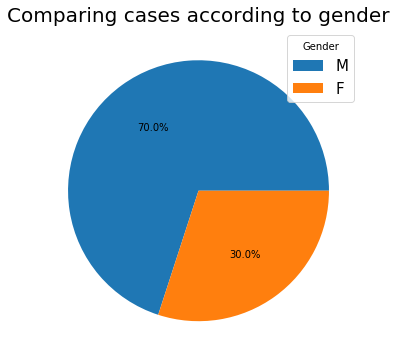

```python
gender=ds1.gender
gender.dropna(inplace=True)
gender=gender.value_counts()
per=[]
for i in gender:
    perc=i/gender.sum()
    per.append(format(perc,'.2f'))
plt.figure(figsize=(10,6))
plt.title('Comparing cases according to gender',fontsize=20)
plt.pie(per,autopct='%1.1f%%')
plt.legend(gender.index,loc='best',title='Gender',fontsize=15)
plt.show()
```

# OBSERVATION:-

## A number of factors may be working against men in the current situation such as lifestyle activities, biological reasons and even immunity system. When it comes to mounting an immune response against infections, men are the weaker sex. Yes, you read that right. Women have a greater ability to fight against infections and diseases than men.

## In addition to all the working women are less than the men in india that's why women are less infected to the corona virus wrt to the men.

```python
import xlrd

ds0=xlrd.open_workbook("complete.xlsx")
sheet=ds.sheet_by_index(0)
sheet.cell_value(0,0)
print(sheet.nrows)
```

```
12322
```

```python
print(sheet.ncols)
```

```
18
```

```python
import pandas as pd

ds2=pd.read_excel("complete.xlsx")
```

```python
ds2.head()
```

|  | Name of State / UT | Total Confirmed cases | Cured/Discharged/Migrated | Death | Date | Latitude | Longitude |
| --- | --- | --- | --- | --- | --- | --- | --- |
| 0 | NaN | NaN | NaN | NaN | NaT | NaN | NaN |
| 1 | Andaman and Nicobar Islands | 14.0 | 11.0 | 0.0 | 2020-04-19 | 11.7401 | 92.6586 |
| 2 | Andhra Pradesh | 603.0 | 42.0 | 15.0 | 2020-04-19 | 15.9129 | 79.7400 |
| 3 | Arunachal Pradesh | 1.0 | 0.0 | 0.0 | 2020-04-19 | 28.2180 | 94.7278 |
| 4 | Assam | 35.0 | 12.0 | 1.0 | 2020-04-19 | 26.2006 | 92.9376 |

```python
ds2.dtypes
```

```
Name of State / UT                   object
Total Confirmed cases               float64
Cured/Discharged/Migrated           float64
Death                               float64
Date                         datetime64[ns]
Latitude                            float64
Longitude                           float64
dtype: object
```

# PROBLEM STATEMENT

TO SHOW THE PERCENTAGE AND THE NUMBET OF PATIENT BY THEIT CURRENT STATUS

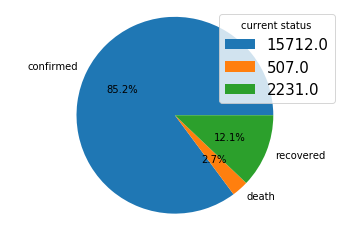

```python
import matplotlib.pyplot as plt

confirmed1=ds2['Total Confirmed cases'].sum()
death=ds2['Death'].sum()
recovered=ds2['Cured/Discharged/Migrated'].sum()
lables=['confirmed','death','recovered']
total = [confirmed1,death,recovered]

fig1, ax1 = plt.subplots()
ax1.pie(total,labels=lables, autopct='%1.1f%%')
ax1.axis('equal')  # Equal aspect ratio ensures that pie is drawn as a circle.
plt.legend(total,loc='best',title='current status',fontsize=15)
plt.show()
```

## OBSEVATION:-

### The recovery rate was nearly 13% as per government figures released on Friday last week, which was a steady improvement from the previous week’s 8%

```python
import os
import matplotlib.pyplot as plt
import matplotlib.dates as mdates
from matplotlib.dates import DateFormatter
import seaborn as sns
import pandas as pd
import numpy as np
```

# PROBLEM SATEMENT

TO SHOW THE TOTAL PERSON INFECTED ,RECOVERED

```python
print('total confirmed cases in India:-'+str(ds2['Total Confirmed cases'].sum()))

print('recovered cases in India:-'+str(ds2['Cured/Discharged/Migrated'].sum()))
```

```
total confirmed cases in India:-15712.0
recovered cases in India:-2231.0
```

# PROBLEM SATEMENT

TO SHOW THE SATEWISE VISLUALISATION V/S CURRENT STATUS IN SUB 3 PARTS

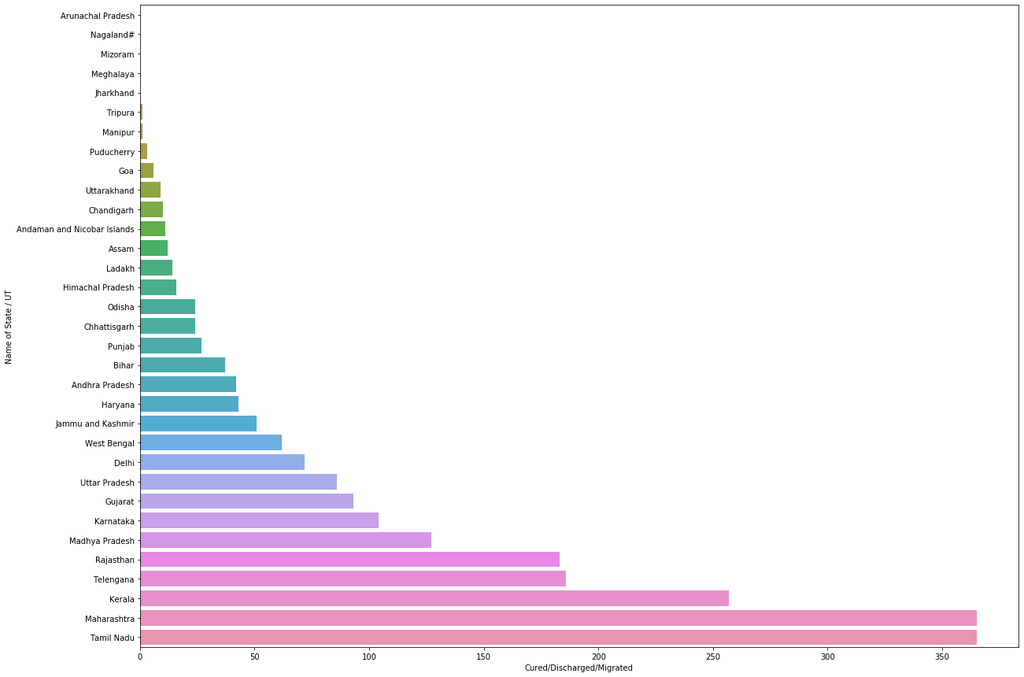

|  | Name of State / UT | Cured/Discharged/Migrated |
| --- | --- | --- |
| 2 | Arunachal Pradesh | 0.0 |
| 22 | Nagaland# | 0.0 |
| 21 | Mizoram | 0.0 |
| 20 | Meghalaya | 0.0 |
| 13 | Jharkhand | 0.0 |
| 29 | Tripura | 1.0 |
| 19 | Manipur | 1.0 |
| 24 | Puducherry | 3.0 |
| 8 | Goa | 6.0 |
| 31 | Uttarakhand | 9.0 |
| 5 | Chandigarh | 10.0 |
| 0 | Andaman and Nicobar Islands | 11.0 |
| 3 | Assam | 12.0 |
| 16 | Ladakh | 14.0 |
| 11 | Himachal Pradesh | 16.0 |
| 23 | Odisha | 24.0 |
| 6 | Chhattisgarh | 24.0 |
| 25 | Punjab | 27.0 |
| 4 | Bihar | 37.0 |
| 1 | Andhra Pradesh | 42.0 |
| 10 | Haryana | 43.0 |
| 12 | Jammu and Kashmir | 51.0 |
| 32 | West Bengal | 62.0 |
| 7 | Delhi | 72.0 |
| 30 | Uttar Pradesh | 86.0 |
| 9 | Gujarat | 93.0 |
| 14 | Karnataka | 104.0 |
| 17 | Madhya Pradesh | 127.0 |
| 26 | Rajasthan | 183.0 |
| 28 | Telengana | 186.0 |
| 15 | Kerala | 257.0 |
| 18 | Maharashtra | 365.0 |
| 27 | Tamil Nadu | 365.0 |

```python
## GARPH 1
## STATES V/S CURED

plt.figure(figsize=(20,15))
result2 = ds2.groupby(['Name of State / UT'])['Cured/Discharged/Migrated'].aggregate(np.median).reset_index().sort_values('Cured/Discharged/Migrated')
sns.barplot(x=ds2['Cured/Discharged/Migrated'], y=ds2['Name of State / UT'], data=ds2, order=result2['Name of State / UT'])
#formerly: sns.barplot(x='Id', y="Speed", data=df, palette=colors, order=result['Id']

plt.show()
result2
```

## obsevation:-

### 1. From the graph we can se that the recovered patient in maharashtra and tamil Nadu is 365 both.

### 2. The recovery rate is maximum in the southern region of the india as conmaped to other states.

### 3. But these states has more number of the tourists therefore these states have more number of the positive cases also.

### 4. They have medical facility as to deal with the corona with better treatment facilities.

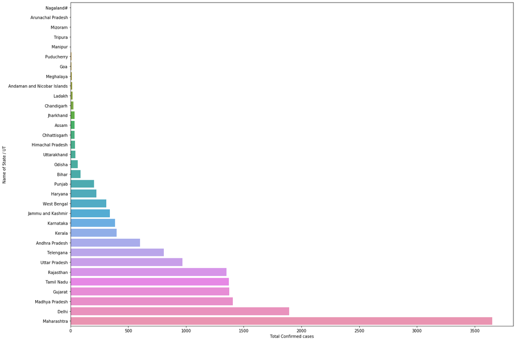

|  | Name of State / UT | Total Confirmed cases |
| --- | --- | --- |
| 22 | Nagaland# | 0.0 |
| 2 | Arunachal Pradesh | 1.0 |
| 21 | Mizoram | 1.0 |
| 29 | Tripura | 2.0 |
| 19 | Manipur | 2.0 |
| 24 | Puducherry | 7.0 |
| 8 | Goa | 7.0 |
| 20 | Meghalaya | 11.0 |
| 0 | Andaman and Nicobar Islands | 14.0 |
| 16 | Ladakh | 18.0 |
| 5 | Chandigarh | 23.0 |
| 13 | Jharkhand | 34.0 |
| 3 | Assam | 35.0 |
| 6 | Chhattisgarh | 36.0 |
| 11 | Himachal Pradesh | 39.0 |
| 31 | Uttarakhand | 42.0 |
| 23 | Odisha | 61.0 |
| 4 | Bihar | 86.0 |
| 25 | Punjab | 202.0 |
| 10 | Haryana | 225.0 |
| 32 | West Bengal | 310.0 |
| 12 | Jammu and Kashmir | 341.0 |
| 14 | Karnataka | 384.0 |
| 15 | Kerala | 400.0 |
| 1 | Andhra Pradesh | 603.0 |
| 28 | Telengana | 809.0 |
| 30 | Uttar Pradesh | 969.0 |
| 26 | Rajasthan | 1351.0 |
| 27 | Tamil Nadu | 1372.0 |
| 9 | Gujarat | 1376.0 |
| 17 | Madhya Pradesh | 1407.0 |
| 7 | Delhi | 1893.0 |
| 18 | Maharashtra | 3651.0 |

```python
## GARPH 2
## STATES V/S CONFIRMED

plt.figure(figsize=(20,15))
result1 = ds2.groupby(['Name of State / UT'])['Total Confirmed cases'].aggregate(np.median).reset_index().sort_values('Total Confirmed cases')
sns.barplot(x=ds2['Total Confirmed cases'], y=ds2['Name of State / UT'], data=ds2, order=result1['Name of State / UT'])
#formerly: sns.barplot(x='Id', y="Speed", data=df, palette=colors, order=result['Id']

plt.show()
result1
```

## OBSERVATION:-

## 1. It can be observed that the Eleven big states account for all of the red zone districts. These include some of India’s most prosperous states such as Delhi, Maharashtra, Gujarat, and Tamil Nadu.

## 2. it may be because of the reson that they are the hub of IT technology, employement and also the marketing industries

## That is why the confirmed cases are more in these states.

```python
ds2.dtypes
```

```
Name of State / UT                   object
Total Confirmed cases               float64
Cured/Discharged/Migrated           float64
Death                               float64
Date                         datetime64[ns]
Latitude                            float64
Longitude                           float64
dtype: object
```

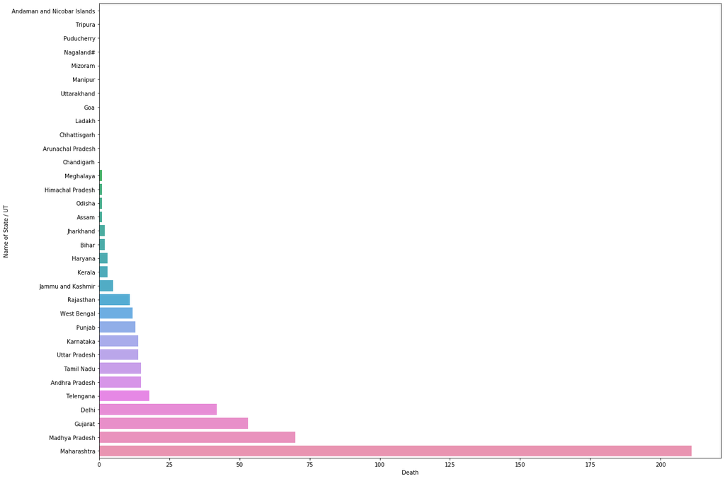

|  | Name of State / UT | Death |
| --- | --- | --- |
| 0 | Andaman and Nicobar Islands | 0.0 |
| 29 | Tripura | 0.0 |
| 24 | Puducherry | 0.0 |
| 22 | Nagaland# | 0.0 |
| 21 | Mizoram | 0.0 |
| 19 | Manipur | 0.0 |
| 31 | Uttarakhand | 0.0 |
| 8 | Goa | 0.0 |
| 16 | Ladakh | 0.0 |
| 6 | Chhattisgarh | 0.0 |
| 2 | Arunachal Pradesh | 0.0 |
| 5 | Chandigarh | 0.0 |
| 20 | Meghalaya | 1.0 |
| 11 | Himachal Pradesh | 1.0 |
| 23 | Odisha | 1.0 |
| 3 | Assam | 1.0 |
| 13 | Jharkhand | 2.0 |
| 4 | Bihar | 2.0 |
| 10 | Haryana | 3.0 |
| 15 | Kerala | 3.0 |
| 12 | Jammu and Kashmir | 5.0 |
| 26 | Rajasthan | 11.0 |
| 32 | West Bengal | 12.0 |
| 25 | Punjab | 13.0 |
| 14 | Karnataka | 14.0 |
| 30 | Uttar Pradesh | 14.0 |
| 27 | Tamil Nadu | 15.0 |
| 1 | Andhra Pradesh | 15.0 |
| 28 | Telengana | 18.0 |
| 7 | Delhi | 42.0 |
| 9 | Gujarat | 53.0 |
| 17 | Madhya Pradesh | 70.0 |
| 18 | Maharashtra | 211.0 |

```python
## GARPH 3
## STATES V/S DEATH

plt.figure(figsize=(20,15))
result = ds2.groupby(['Name of State / UT'])['Death'].aggregate(np.median).reset_index().sort_values('Death')
g=sns.barplot(x=ds2['Death'], y=ds2['Name of State / UT'], data=ds2, order=result['Name of State / UT'])
#formerly: sns.barplot(x='Id', y="Speed", data=df, palette=colors, order=result['Id']

plt.show()
result
```

## OBSERVATION:-

### 1. Given that testing has been uneven across the country, it is difficult to say to what extent the reporting of cases across regions reflects actual incidence, and to what extent it reflects the scale of testing. If the extent of under-reporting is not high and the confirmed cases reflect the true spread of covid-19 in India, it could simply imply the better integration of urbanized and densely packed districts with the rest of the country and the world. In normal years, these features make these districts attractive destinations for migrants.

### 2. the first coronavirus case was also confirmed in Mumbai’s Dharavi slum, which is India’s largest and is home to almost one million people living in close, unsanitary quarters.

### 3. All above are the reason for the deaths in urban cities.

```python
import os
import matplotlib.pyplot as plt
import matplotlib.dates as mdates
from matplotlib.dates import DateFormatter
```

## PROBLEM STATEMENT:-

### DATE WISE ANAYSIS OF THE CONFIRMED CASES

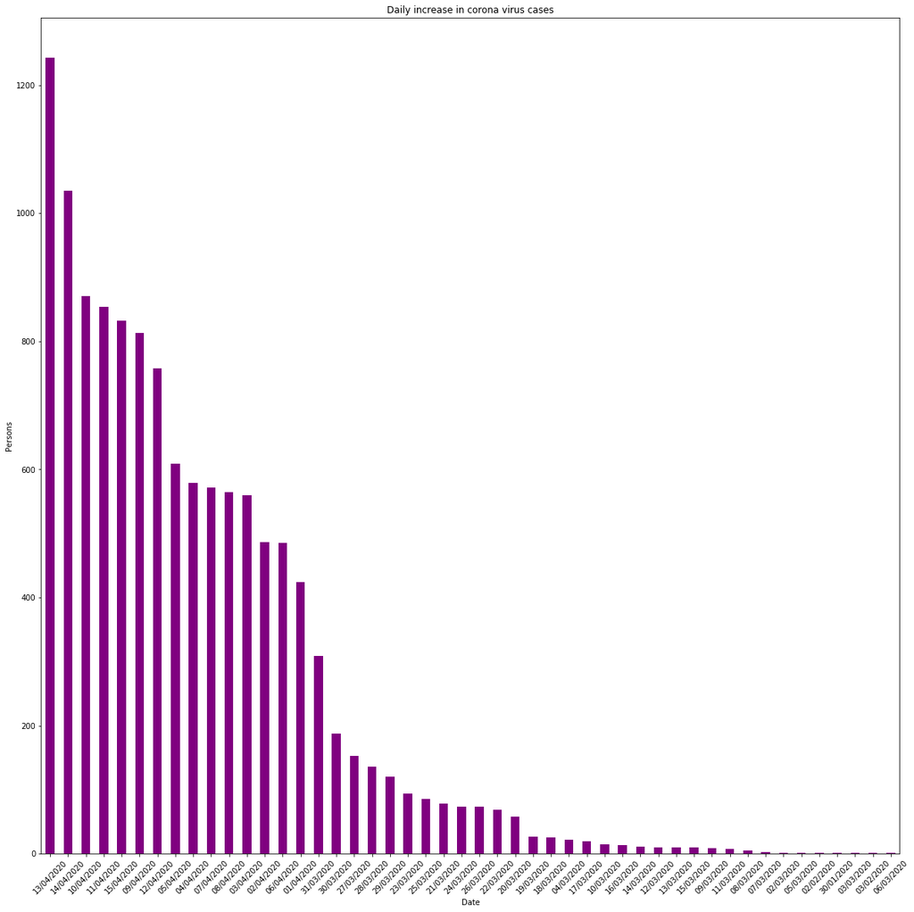

```python
fig, ax = plt.subplots(figsize=(20, 10))
d=ds1['date_announced'].value_counts()
d.plot(kind='bar', figsize=(20,20),color='purple')
ax.set(xlabel="Date",
       ylabel="Persons",
       title="Daily increase in corona virus cases")

# Rotate tick marks on x-axis
plt.setp(ax.get_xticklabels(), rotation=45)
plt.show()
```

```python
ds1['date_announced'].value_counts()
```

```
13/04/2020    1243
14/04/2020    1035
10/04/2020     871
11/04/2020     854
15/04/2020     832
09/04/2020     813
12/04/2020     758
05/04/2020     609
04/04/2020     579
07/04/2020     572
08/04/2020     565
03/04/2020     560
02/04/2020     486
06/04/2020     485
01/04/2020     424
31/03/2020     309
30/03/2020     187
27/03/2020     153
28/03/2020     136
29/03/2020     120
23/03/2020      94
25/03/2020      86
21/03/2020      78
24/03/2020      74
26/03/2020      73
22/03/2020      69
20/03/2020      58
19/03/2020      27
18/03/2020      25
04/03/2020      22
17/03/2020      20
10/03/2020      15
16/03/2020      14
14/03/2020      11
12/03/2020      10
13/03/2020      10
15/03/2020      10
09/03/2020       9
11/03/2020       8
08/03/2020       5
07/03/2020       3
02/03/2020       2
05/03/2020       2
02/02/2020       1
30/01/2020       1
03/03/2020       1
03/02/2020       1
06/03/2020       1
Name: date_announced, dtype: int64
```

## Obsevation:-

##### 12/04/2020 758

##### 13/04/2020 1243 (highest count)

##### 14/04/2020 1035

##### 15/04/2020 832

```python
d.describe()
```

```
count      48.000000
mean      256.687500
std       339.522265
min         1.000000
25%        10.000000
50%        73.500000
75%       504.500000
max      1243.000000
Name: date_announced, dtype: float64
```

```
0        20
3        45
4        24
5        69
6        55
         ..
11593    25
11594    60
11595    60
11760    28
11761    80
Name: age_bracket, Length: 1507, dtype: object
```

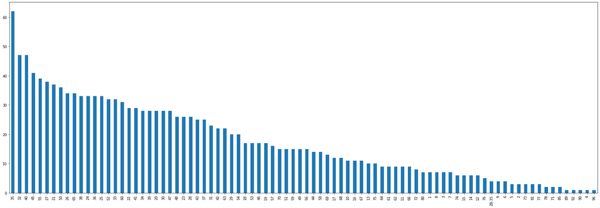

```python
fig, ax = plt.subplots(figsize=(30, 10))
ds1['age_bracket'].dropna()
ds1['age_bracket'].value_counts().plot(kind='bar')
d=ds1['age_bracket'].value_counts()
ds1['age_bracket'].dropna()
```

```python
ds1['age_bracket'].describe()
```

```
count     1507
unique      86
top         35
freq        62
Name: age_bracket, dtype: object
```

# PROBLEM SATEMENT

AGE GROUP WISE INFECTED ANAYASIS

```python
age_details = pd.read_csv('AgeGroupDetails.csv')
```

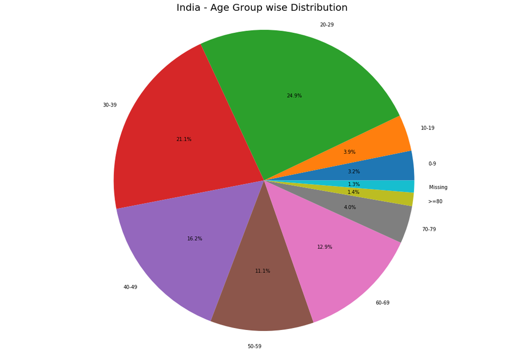

```python
labels = list(age_details['AgeGroup'])
sizes = list(age_details['TotalCases'])




plt.figure(figsize= (15,10))
plt.pie(sizes, labels=labels, autopct='%1.1f%%')


fig = plt.gcf()

plt.title('India - Age Group wise Distribution',fontsize = 20)
plt.axis('equal')
plt.tight_layout()
```

## Observation:-

#### 5. The ministry's analysis confirms an India Today Data Intelligence Unit report that found that the novel coronavirus has so far infected mostly the working-age population in India.

```python
india_covid_19 = pd.read_csv('covid_19_india.csv')
hospital_beds = pd.read_csv('HospitalBedsIndia.csv')
individual_details = pd.read_csv('IndividualDetails.csv')
ICMR_details = pd.read_csv('ICMRTestingDetails.csv')
ICMR_labs = pd.read_csv('ICMRTestingLabs.csv')
state_testing = pd.read_csv('StatewiseTestingDetails.csv')
population = pd.read_csv('population_india_census2011.csv')
```

```python
hospital_beds =hospital_beds.drop([36])
cols_object = list(hospital_beds.columns[2:8])

for cols in cols_object:
    hospital_beds[cols] = hospital_beds[cols].astype(int,errors = 'ignore')
```

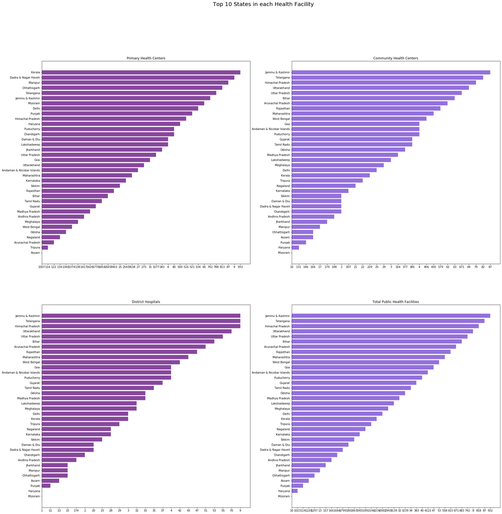

```python
top_10_primary =hospital_beds.sort_values('NumPrimaryHealthCenters_HMIS').groupby('NumPrimaryHealthCenters_HMIS').head(10)
top_10_community = hospital_beds.sort_values('NumCommunityHealthCenters_HMIS').groupby('NumCommunityHealthCenters_HMIS').head(10)
top_10_district_hospitals = hospital_beds.sort_values('NumDistrictHospitals_HMIS').groupby('NumDistrictHospitals_HMIS').head(10)
top_10_public_facility = hospital_beds.sort_values('TotalPublicHealthFacilities_HMIS').groupby('TotalPublicHealthFacilities_HMIS').head(10)
top_10_public_beds = hospital_beds.sort_values('NumPublicBeds_HMIS').groupby('NumPublicBeds_HMIS').head(10)

top_10_primary.dropna(how='all')
top_10_community.dropna(how='all')
top_10_district_hospitals.dropna(how='all')
top_10_public_facility.dropna(how='all')
top_10_public_beds.dropna(how='all')

plt.figure(figsize=(30,30))
plt.suptitle('Top 10 States in each Health Facility',fontsize=20)
plt.subplot(221)
plt.title('Primary Health Centers')
plt.barh(top_10_primary['State/UT'].dropna(),top_10_primary['NumPrimaryHealthCenters_HMIS'].dropna(),color ='#87479d');

plt.subplot(222)
plt.title('Community Health Centers')
plt.barh(top_10_community['State/UT'].dropna(),top_10_community['NumCommunityHealthCenters_HMIS'].dropna(),color = '#9370db');

plt.subplot(224)
plt.title('Total Public Health Facilities')
plt.barh(top_10_community['State/UT'].dropna(),top_10_public_facility['TotalPublicHealthFacilities_HMIS'].dropna(),color='#9370db');

plt.subplot(223)
plt.title('District Hospitals')
plt.barh(top_10_community['State/UT'].dropna(),top_10_district_hospitals['NumDistrictHospitals_HMIS'].dropna(),color = '#87479d');
```

## satewise testing centers in India

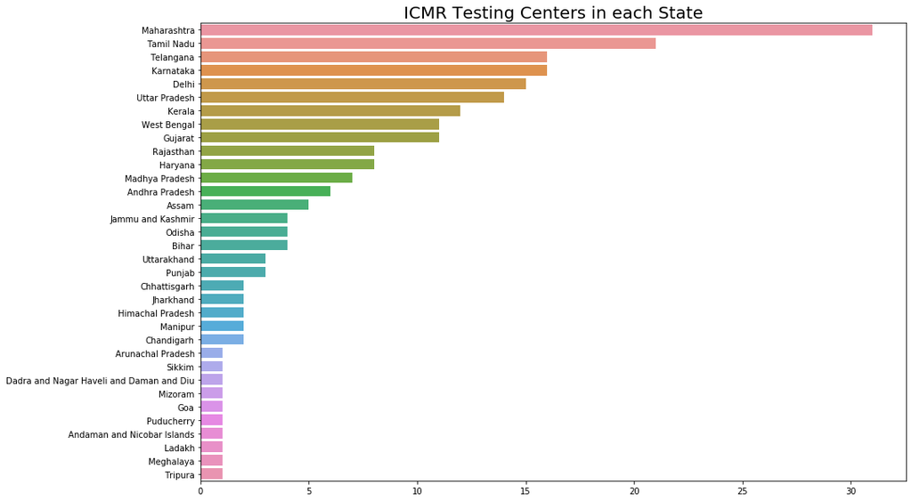

```
Maharashtra                                 31
Tamil Nadu                                  21
Telangana                                   16
Karnataka                                   16
Delhi                                       15
Uttar Pradesh                               14
Kerala                                      12
West Bengal                                 11
Gujarat                                     11
Rajasthan                                    8
Haryana                                      8
Madhya Pradesh                               7
Andhra Pradesh                               6
Assam                                        5
Jammu and Kashmir                            4
Odisha                                       4
Bihar                                        4
Uttarakhand                                  3
Punjab                                       3
Chhattisgarh                                 2
Jharkhand                                    2
Himachal Pradesh                             2
Manipur                                      2
Chandigarh                                   2
Arunachal Pradesh                            1
Sikkim                                       1
Dadra and Nagar Haveli and Daman and Diu     1
Mizoram                                      1
Goa                                          1
Puducherry                                   1
Andaman and Nicobar Islands                  1
Ladakh                                       1
Meghalaya                                    1
Tripura                                      1
Name: state, dtype: int64
```

```python
values = list(ICMR_labs['state'].value_counts())
names = list(ICMR_labs['state'].value_counts().index)

plt.figure(figsize=(15,10))
sns.set_color_codes("pastel")
plt.title('ICMR Testing Centers in each State', fontsize = 20)
sns.barplot(x= values, y= names)
plt.show()
ICMR_labs['state'].value_counts()
```

# OBSERVATION:-

#### 1.From the above graph we can observe that the states which are having more number of confirmed cases of corona has more number of testing center.

#### 2. Also these states are having more population and are hub of trade and marketing.Which leads them to have more number of corona positive cases.

## statewise health facility (bed for patient)

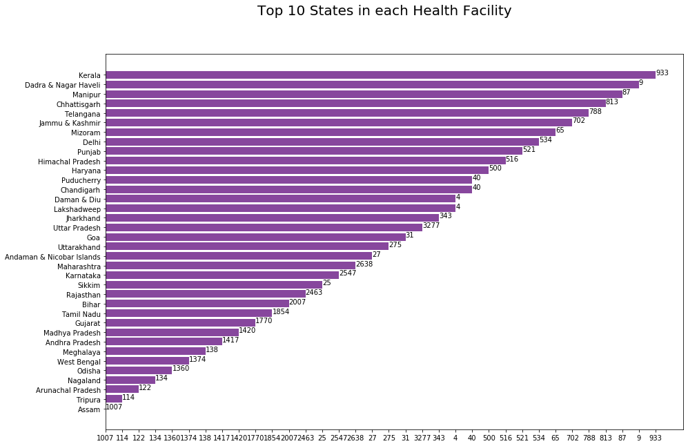

```python
plt.figure(figsize=(15,10))
plt.suptitle('Top 10 States in each Health Facility',fontsize=20)
plt.barh(top_10_primary['State/UT'].dropna(),top_10_primary['NumPrimaryHealthCenters_HMIS'].dropna(),color ='#87479d');
for index, value in enumerate(top_10_primary['NumPrimaryHealthCenters_HMIS'].dropna()):
    plt.text(value, index, str(value))
```

## State wise community health centers(bed for patient)

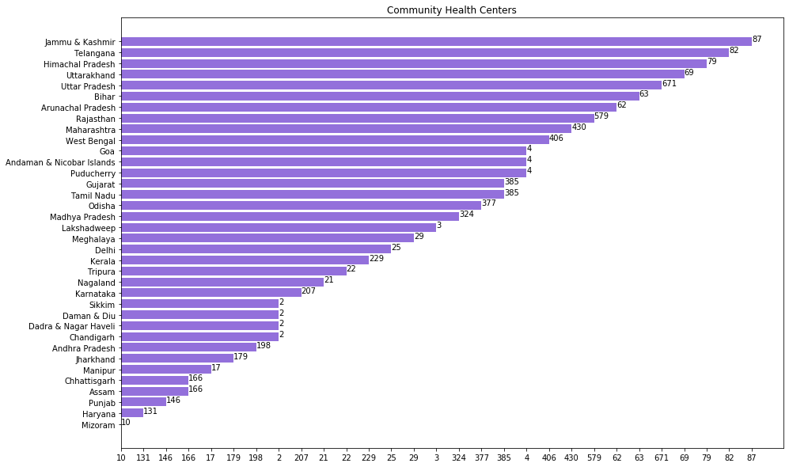

```python
plt.figure(figsize=(15,10))
plt.title('Community Health Centers')
plt.barh(top_10_community['State/UT'].dropna(),top_10_community['NumCommunityHealthCenters_HMIS'].dropna(),color = '#9370db');
for index, value in enumerate(top_10_community['NumCommunityHealthCenters_HMIS'].dropna()):
    plt.text(value, index, str(value))
```

## state wise Public Health Facility(bed for patient)

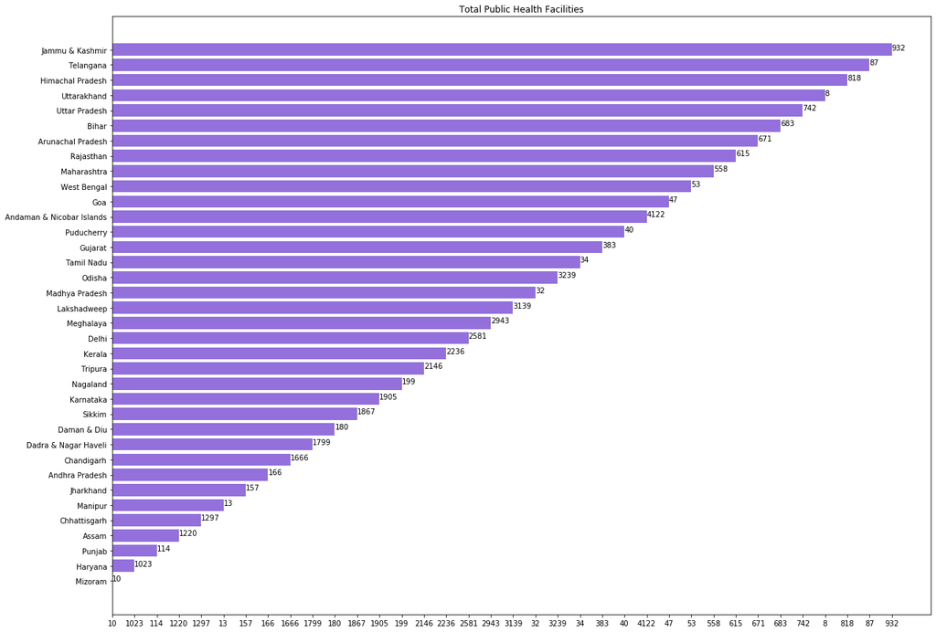

```python
plt.figure(figsize=(20,15))
plt.title('Total Public Health Facilities')
plt.barh(top_10_community['State/UT'].dropna(),top_10_public_facility['TotalPublicHealthFacilities_HMIS'].dropna(),color='#9370db')

for index, value in enumerate(top_10_public_facility['TotalPublicHealthFacilities_HMIS'].dropna()):
    plt.text(value, index, str(value))
```

## state wise district hospitals(bed for patient)

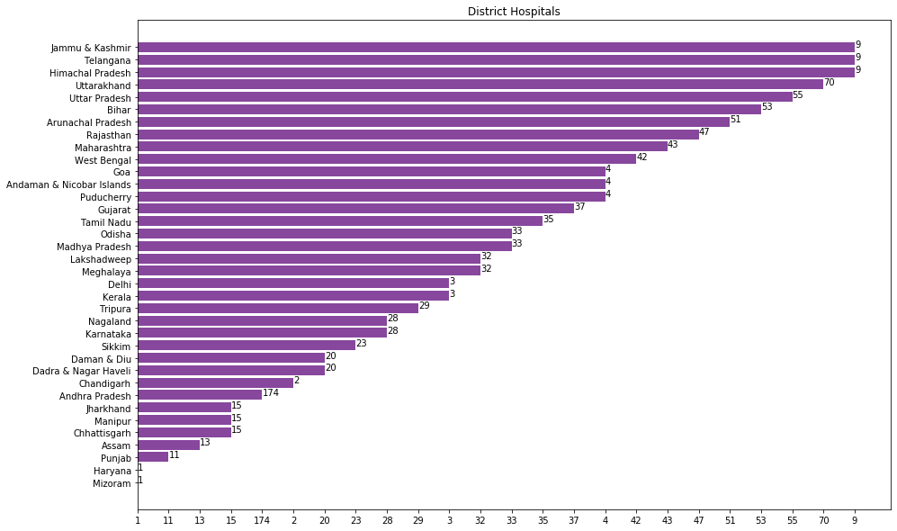

```python
plt.figure(figsize=(15,10))
plt.title('District Hospitals')
plt.barh(top_10_community['State/UT'].dropna(),top_10_district_hospitals['NumDistrictHospitals_HMIS'].dropna(),color = '#87479d')

for index, value in enumerate(top_10_district_hospitals['NumDistrictHospitals_HMIS'].dropna()):
    plt.text(value, index, str(value))
```

# Observation from above 4 graphs :-

# Symtoms of COVID-19

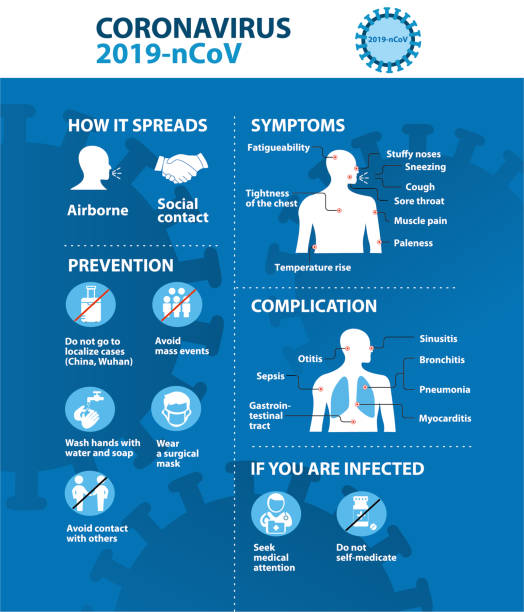

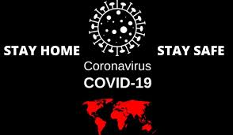

# THANK YOU

# REG.NO. 11609198